# X1005261001-Bagas Febry Gunawan

Author

Bagas Febry Gunawan

## Tugas Praktikum STA2561

### Soal 1

Buatlah pseudocode dan flowchart untuk menentukan apakah sebuah bilangan bulat yang dimasukkan pengguna merupakan bilangan genap atau ganjil.

**Note**

Pseudocode

Flowchart

```
Mulai

INPUT: bilangan bulat (integer)

PROCESS:
Percabangan dengan kondisi:
Jika dibagi 2 menghasilkan sisaan = 1

TRUE:
OUTPUT: Tampilkan "Bilangan Ganjil"

FALSE:
OUTPUT: Tampilkan "Bilangan Genap"

Selesai
```

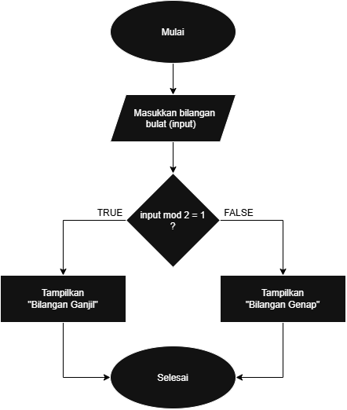

### Soal 2

Jelaskan jenis struktur algoritma di bawah ini dan berikan alasannya.

```
Mulai
Input panjang
Input lebar
luas <- panjang * lebar
keliling <- 2 * (panjang + lebar)
Output luas
Output keliling
Selesai
```

**Note**

Jenis struktur algoritma di atas adalah Runtunan, karena pada algoritma cukup sederhana, setiap tahapan demi tahapan pada algoritma berjalan secara seri dari tahapan Mulai, Input, Process, Output, dan Selesai, tidak ada percabangan ataupun perulangan.

### Soal 3

Buatlah algoritma untuk menentukan kategori nilai mahasiswa dengan ketentuan:

- Nilai ≥ 80 → `"Baik"`
- Nilai 60–79 → `"Cukup"`
- Nilai < 60 → `"Kurang"`

Tuliskan algoritma tersebut dalam bentuk pseudocode.

**Note**

Algoritma pengkategorian nilai mahasiswa

1. Mulai
2. import data nilai
3. Buat kolom kategori pada data nilai
4. Isi kolom kategori dengan kondisi: Jika nilai >= 80
   - TRUE: “Baik”
   - FALSE: cek kondisi: Jika nilai >= 60 #hanya memeriksa apakah nilai >= 60 karena sudah false ketika kondisi >= 80, sehingga kondisi TRUE pada kondisi ini mencakup nilai 60 - 79
     - TRUE: “Cukup”
     - FALSE: “Kurang”
5. Selesai

### Soal 4

Buat sebuah vektor berisi bilangan genap dari 2 sampai 20. Hitung jumlah elemen dan rata-ratanya.

**Note**

```r
# generate data
a <- 1:20
#filter data genap
genap <- a[a %% 2 == 0]
genap
```

```
 [1]  2  4  6  8 10 12 14 16 18 20
```

```r
#jumlah elemen
paste("Jumlah elemen:",length(genap))
```

```
[1] "Jumlah elemen: 10"
```

```r
#hitung rataan
paste("Rataan:",mean(genap))
```

```
[1] "Rataan: 11"
```

### Soal 5

Buat matriks 3×3 berisi angka 1 sampai 9, tampilkan transpose dan determinannya

**Note**

```r
# buat matrix
mat <- matrix(1:9, nrow = 3, ncol = 3)
mat #Matrix:
```

```
     [,1] [,2] [,3]
[1,]    1    4    7
[2,]    2    5    8
[3,]    3    6    9
```

```r
#transpose
tmat<-t(mat)
tmat #Transpose Matrix:
```

```
     [,1] [,2] [,3]
[1,]    1    2    3
[2,]    4    5    6
[3,]    7    8    9
```

```r
#determinan
determinan<-det(mat)
paste("Determinan Matrix:",determinan)
```

```
[1] "Determinan Matrix: 0"
```

### Soal 6

Diketahui string:

```
x <- "Pemrograman Statistik R"
```

Hitung jumlah karakter dan ambil kata “Statistik”

**Note**

```r
x <- "Pemrograman Statistik R"
paste("Jumlah Karakter:",nchar(x))
```

```
[1] "Jumlah Karakter: 23"
```

```r
#Ambil kata "Statistik"
subs<-substring(x,first = 13, last = nchar(x)-2)
subs
```

```
[1] "Statistik"
```

### Soal 7

Buat `data.frame` dengan kolom: `Nama`, `Umur`, `Nilai`. Isi dengan minimal 3 baris data. Tampilkan hanya baris dengan `Nilai >= 80`.

**Note**

```r
data<-data.frame(
  Nama=c("Agus", "Bagus", "Cagus"),
  Umur=sample(20:35,3),
  Nilai=c(81,76,99)
)
data
```

```
   Nama Umur Nilai
1  Agus   22    81
2 Bagus   28    76
3 Cagus   27    99
```

```r
print("Data dengan Nilai >80:")
```

```
[1] "Data dengan Nilai >80:"
```

```r
data[data$Nilai>80,]
```

```
   Nama Umur Nilai
1  Agus   22    81
3 Cagus   27    99
```

### Soal 8

Diberikan vektor:

```
a <- 1:8
b <- c(2, 4)
```

Lakukan `a * b` dan jelaskan kenapa hasilnya demikian.

```r
a <- 1:8
b <- c(2, 4)
print(a*b)
```

```
[1]  2  8  6 16 10 24 14 32
```

**Note**

a merupakan vector berukuran 8 elemen yang terdiri dari nilai 1 hingga 8. Sedangkan b merupakan vector berukuran 2 elemen yang terdiri dari nilai 2 dan 4.

Sehingga, ketika dilakukan operasi a*b akan menghasilkan perkalian vector dimensi 8 dengan vector dimensi 2 yang direcycle sebanyak 4 kali hingga menghasilkan 8 elemen.

**Tip**

Ilustrasi:

```
1  2  3  4  5  6  7  8
*
2  4  2  4  2  4  2  4
=
2  8  6 16 10 24 14 32
```

### Soal 9

Buat kode yang membaca satu nilai bilangan bulat `x`. Jika:

- `x > 0` cetak “positif”
- `x < 0` cetak “negatif”
- `x = 0` cetak “nol”

**Note**

```r
#meminta input dari user
#x <- as.integer(readline("Masukkan bilangan bulat: "))
#tapi pada quatro tidak bisa dibuat dinamis seperti itu, x harus langsung terdefinisi,
#maka dicoba dengan iterasi dari vector x yang memuat bilangan positif, negatif dan nol.

x<-c(5,-2,0)
for(i in x) {
  if(i>0) {
    print(paste("Bilangan",i,"Positif"))
  } else {
    if(i<0) {
      print(paste("Bilangan",i,"Negatif"))
    } else {
      print(paste("Bilangan",i,"Nol"))
    }
  }
}
```

```
[1] "Bilangan 5 Positif"
[1] "Bilangan -2 Negatif"
[1] "Bilangan 0 Nol"
```

### Soal 10

Tuliskan kode R untuk menghitung jumlah kuadrat dari 1 sampai 10 menggunakan perulangan `for`. (Petunjuk: hasil akhir adalah 1²+2²+…+10²).

**Note**

```r
a<-0
kuadrat<-c()
for(i in 1:10) {
  a=a+i^2
  kuadrat=c(kuadrat,i^2)
}
print(paste(kuadrat[1],"+",kuadrat[2],"+",kuadrat[3],"+",kuadrat[4],"+",kuadrat[5],"+",kuadrat[6],"+",kuadrat[7],"+",kuadrat[8],"+",kuadrat[9],"+",kuadrat[10],"=",a))
```

```
[1] "1 + 4 + 9 + 16 + 25 + 36 + 49 + 64 + 81 + 100 = 385"
```

### Soal 11

Tuliskan kode R untuk menampilkan 10 suku pertama deret Fibonacci menggunakan perulangan `while`

**Note**

Deret Fibonacci adalah deret bilangan di mana setiap suku merupakan penjumlahan dari dua suku sebelumnya.

```r
i<-1
j<-c()
while(i<=10) {
  if(i==1) {
    j<-c(j,0)
  } else {
    if(i==2) {
      j<-c(j,i-1+j[i-1])
    } else {
      j<-c(j,j[i-1]+j[i-2])
    }
  }
  i=i+1
}
print(j)
```

```
 [1]  0  1  1  2  3  5  8 13 21 34
```

### Soal 12

Tuliskan kode R untuk mencari bilangan bulat positif terkecil yang jika dipangkatkan 2 menghasilkan nilai lebih dari 200 menggunakan perulangan `repeat`.

**Note**

```r
i<-0
repeat {
  if(i^2>200) {
    break
  } else {
    i=i+1
  }
}
print(paste("Bilangan bulat terkecil yang jika dipangkatkan 2 lebih dari 200 adalah",i))
```

```
[1] "Bilangan bulat terkecil yang jika dipangkatkan 2 lebih dari 200 adalah 15"
```

```r
print(paste0(i,"^2 = ",i^2))
```

```
[1] "15^2 = 225"
```

### Soal 13

Buatlah sebuah program R dengan ketentuan berikut:

- Bentuk sebuah `data.frame` berisi 5 orang dengan kolom `Nama`, `Nilai`.
- Gunakan `ifelse` untuk menambahkan kolom baru bernama `Kategori` dengan aturan:

```
-   Nilai ≥ 85  → "A" -   Nilai 70–84 → "B" -   Nilai < 70  → "C"
```

- Hitung rata-rata nilai tiap kategori.

**Note**

```r
data<-data.frame(
  Nama = c("Agus", "Bagus", "Cagus", "Dagus", "Eagus"),
  Nilai = sample(50:100,5, replace = TRUE)
)
data #data awal
```

```
   Nama Nilai
1  Agus    57
2 Bagus    75
3 Cagus    88
4 Dagus    97
5 Eagus    88
```

```r
data$Kategori<-ifelse(data$Nilai>=85,"A",ifelse(data$Nilai>=70,"B","C"))
data #data dengan penambahan kategori
```

```
   Nama Nilai Kategori
1  Agus    57        C
2 Bagus    75        B
3 Cagus    88        A
4 Dagus    97        A
5 Eagus    88        A
```

```r
#rataan tiap kategori
nilaiA<-data[data$Kategori=="A",2]
nilaiB<-data[data$Kategori=="B",2]
nilaiC<-data[data$Kategori=="C",2]
dataRataan<-data.frame(
  Kategori = c("A", "B", "C"),
  RataanNilai = c(mean(nilaiA), mean(nilaiB), mean(nilaiC))
)
dataRataan
```

```
  Kategori RataanNilai
1        A          91
2        B          75
3        C          57
```